# CS329E Final Project

## Imports and Constants

```python
import pandas as pd
import datetime
from sklearn.preprocessing import StandardScaler
from sklearn.decomposition import PCA
from pandas import DataFrame, Series
import random as rand
from sklearn.manifold import MDS
import matplotlib.pyplot as plt
from sklearn.cluster import DBSCAN
from sklearn.metrics import silhouette_score
from sklearn.neighbors import NearestNeighbors
import seaborn as sns
```

```python
def scatter_label(data, labels, numPoints = 300):

    numEntries = data.shape[0]
    start = rand.randint(0, numEntries - numPoints)
    end = start + numPoints
    data = data.iloc[start:end, :]
    labels = labels.iloc[start:end]

    mds = MDS(n_components=2)
    mds_data = mds.fit_transform(data.iloc[:, :-1])
    plt.scatter(mds_data[:, 0], mds_data[:, 1],c=labels, s=50)
    plt.show()
```

```python
def scatter_nolabel(data, numPoints = 300):

    numEntries = data.shape[0]
    start = rand.randint(0, numEntries - numPoints)
    end = start + numPoints
    data = data.iloc[start:end, :]

    mds = MDS(n_components=2)
    mds_data = mds.fit_transform(data.iloc[:, :-1])
    plt.scatter(mds_data[:, 0], mds_data[:, 1], s=50)
    plt.show()
```

## Data Preparation

### Loading Data

Loading data from CSV file. Taking out unnecessary data such as UID, Name, Date, and City.

```python
data = pd.read_csv("pf.csv", header=0)
data = data.drop("UID", axis = 1)
data = data.drop("Name", axis = 1)
data = data.drop("City", axis=1)
data["Date"] = pd.to_datetime(data["Date"])
data["Day_of_week"] = data["Date"].dt.day_name()
data["Month_of_year"] = data["Date"].dt.month_name()
data["Year"] = pd.DatetimeIndex(data["Date"]).year
data = data.drop("Date", axis=1)
print(data.shape)
data.head(10)
```

```
(12491, 11)
```

|  | Age | Gender | Race | State | Manner_of_death | Armed | Mental_illness | Flee | Day_of_week | Month_of_year | Year |
| --- | --- | --- | --- | --- | --- | --- | --- | --- | --- | --- | --- |
| 0 | 44.0 | Female | Asian | CA | Shot | NaN | False | False | Thursday | May | 2000 |
| 1 | 26.0 | Male | Asian | CA | Shot | NaN | False | False | Friday | June | 2000 |
| 2 | 36.0 | Male | Asian | CA | Shot | Gun | False | False | Sunday | August | 2000 |
| 3 | 29.0 | Male | Asian | CA | Shot | Gun | False | False | Friday | February | 2001 |
| 4 | 25.0 | Male | Asian | CA | Shot | Knife | False | False | Sunday | June | 2001 |
| 5 | 55.0 | Male | Asian | NV | Shot | Knife | False | False | Saturday | June | 2001 |
| 6 | 33.0 | Male | Asian | NY | Shot | NaN | True | False | Saturday | June | 2001 |
| 7 | 29.0 | Male | Asian | OR | Shot | Knife | True | False | Sunday | July | 2001 |
| 8 | 21.0 | Male | Asian | CA | Shot | Gun | False | False | Friday | July | 2001 |
| 9 | 27.0 | Female | Asian | WA | Shot | Gun | False | False | Thursday | August | 2001 |

```python
armed = data["Armed"].copy()

for i in range(len(armed)):
    temp = armed[i]
    if (temp != "Gun" and temp != "Knife" and temp!="Unarmed" and not pd.isna(temp)):
        armed[i] = "Other"

data["Armed"] = armed
```

## Data Exploration

Correlating the different features to age of victim

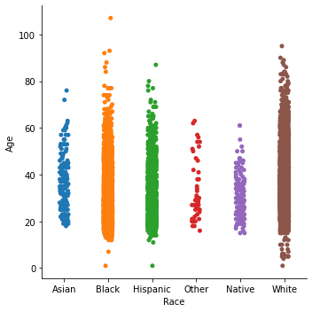

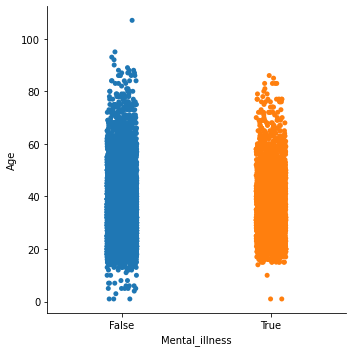

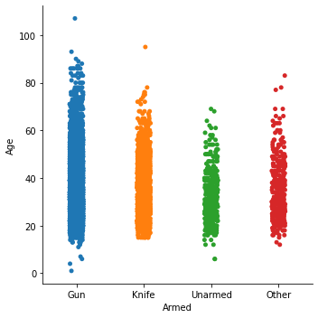

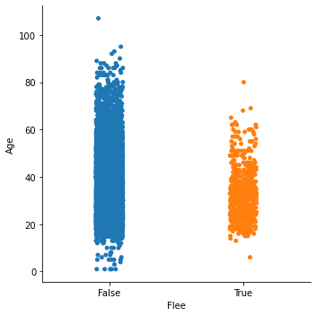

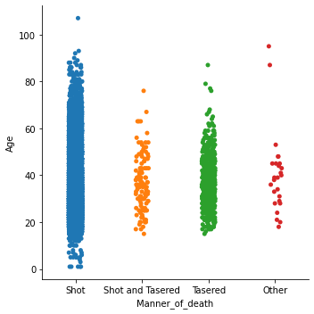

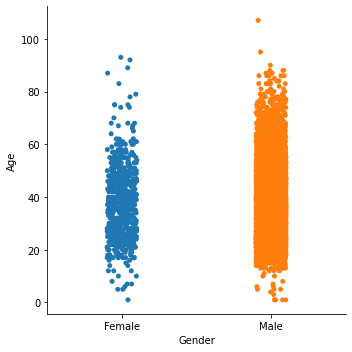

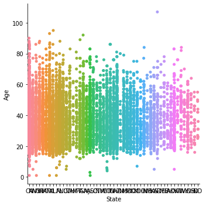

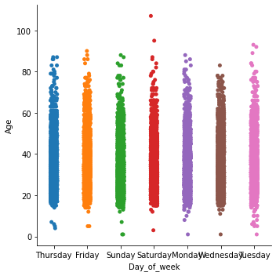

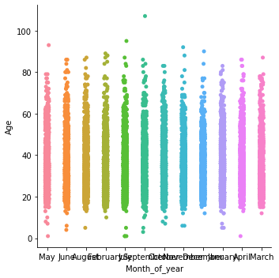

```python
features = ["Race", "Mental_illness", "Armed", "Flee",  "Manner_of_death", "Gender", "State","Day_of_week", "Month_of_year"]
for f in features:
    sns.catplot(x=f, y="Age", data = data);
```

Correlating the different features to the year the shooting happened

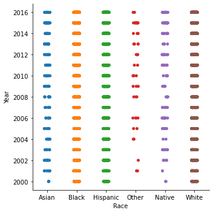

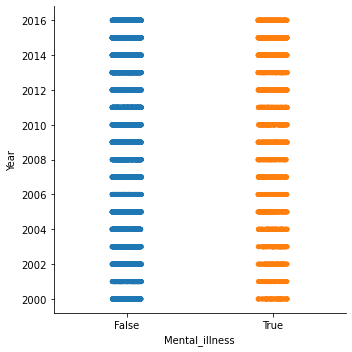

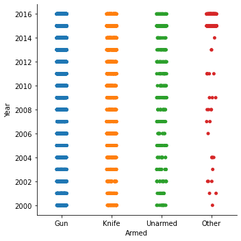

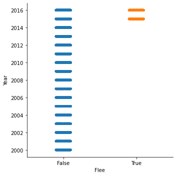

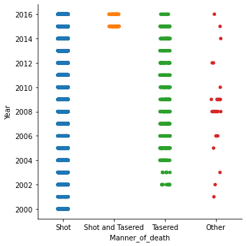

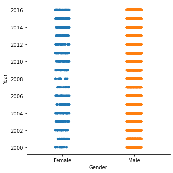

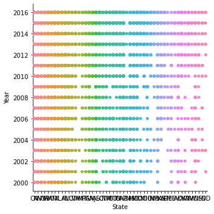

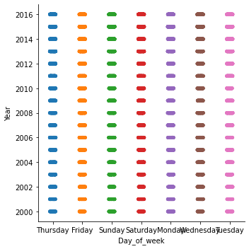

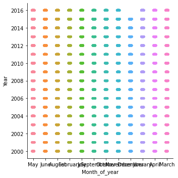

```python
features = ["Race", "Mental_illness", "Armed", "Flee",  "Manner_of_death", "Gender", "State","Day_of_week", "Month_of_year"]
for f in features:
    sns.catplot(x=f, y="Year", data = data);
```

```python
print("Age Missing Values =", data['Age'].isnull().sum())
print("Gender Missing Values =", data['Gender'].isnull().sum())
print("Race Missing Values =", data['Race'].isnull().sum())
print("Day of Week Missing Values =", data['Day_of_week'].isnull().sum())
print("Month of Year Missing Values =", data['Month_of_year'].isnull().sum())
print("Year Values =", data['Year'].isnull().sum())
print("State Missing Values =", data['State'].isnull().sum())
print("Manner of Death Missing Values =", data['Manner_of_death'].isnull().sum())
print("Armed Missing Values =", data['Armed'].isnull().sum())
print("Mental Illness Missing Values =", data['Mental_illness'].isnull().sum())
print("Flee Missing Values =", data['Flee'].isnull().sum())
```

```
Age Missing Values = 233
Gender Missing Values = 8
Race Missing Values = 3965
Day of Week Missing Values = 0
Month of Year Missing Values = 0
Year Values = 0
State Missing Values = 0
Manner of Death Missing Values = 0
Armed Missing Values = 5677
Mental Illness Missing Values = 0
Flee Missing Values = 0
```

# Isolating the other datasets

```python
data = data.drop("Day_of_week", axis=1)
data = data.drop("Month_of_year", axis=1)
data = data.drop("Year", axis=1)
```

### Armed Dataset

We deleted the Race feature on this dataset to isolate Armed.

```python
data_armed = data.drop("Race", axis=1)
print(data_armed.shape)
data_armed.head(10)
```

```
(12491, 7)
```

|  | Age | Gender | State | Manner_of_death | Armed | Mental_illness | Flee |
| --- | --- | --- | --- | --- | --- | --- | --- |
| 0 | 44.0 | Female | CA | Shot | NaN | False | False |
| 1 | 26.0 | Male | CA | Shot | NaN | False | False |
| 2 | 36.0 | Male | CA | Shot | Gun | False | False |
| 3 | 29.0 | Male | CA | Shot | Gun | False | False |
| 4 | 25.0 | Male | CA | Shot | Knife | False | False |
| 5 | 55.0 | Male | NV | Shot | Knife | False | False |
| 6 | 33.0 | Male | NY | Shot | NaN | True | False |
| 7 | 29.0 | Male | OR | Shot | Knife | True | False |
| 8 | 21.0 | Male | CA | Shot | Gun | False | False |
| 9 | 27.0 | Female | WA | Shot | Gun | False | False |

### Race dataset

We deleted the Armed feature to isolate Race.

```python
data_race = data.drop("Armed", axis=1)
print(data_race.shape)
data_race.head(10)
```

```
(12491, 7)
```

|  | Age | Gender | Race | State | Manner_of_death | Mental_illness | Flee |
| --- | --- | --- | --- | --- | --- | --- | --- |
| 0 | 44.0 | Female | Asian | CA | Shot | False | False |
| 1 | 26.0 | Male | Asian | CA | Shot | False | False |
| 2 | 36.0 | Male | Asian | CA | Shot | False | False |
| 3 | 29.0 | Male | Asian | CA | Shot | False | False |
| 4 | 25.0 | Male | Asian | CA | Shot | False | False |
| 5 | 55.0 | Male | Asian | NV | Shot | False | False |
| 6 | 33.0 | Male | Asian | NY | Shot | True | False |
| 7 | 29.0 | Male | Asian | OR | Shot | True | False |
| 8 | 21.0 | Male | Asian | CA | Shot | False | False |
| 9 | 27.0 | Female | Asian | WA | Shot | False | False |

### Hot encoding categorical feature

Features such as Gender, Race, Manner of death, Armed, Mental Illness and Flee

```python
datasets = [data, data_armed, data_race]

for i in range(len(datasets)):
    dataset = datasets[i]
    features = ["Race", "Mental_illness", "Armed", "Flee",  "Manner_of_death", "Gender"]
    for f in features:
        try:
            col = dataset[f]
            col = pd.Categorical(col)
            encoded = pd.get_dummies(col, prefix=f)
            dataset = pd.concat([dataset, encoded], axis=1)
            dataset = dataset.drop(f, axis=1)
        except:
            continue
    datasets[i] = dataset

for d in datasets:
    print(d.shape)
```

```
(12491, 22)
(12491, 16)
(12491, 18)
```

### Cleaning Data

Deleting rows with missing values.

```python
for i in range(len(datasets)):
    d = datasets[i]
    d =d.dropna(axis=0)
    datasets[i] = d

data, data_armed, data_race = datasets
print("Data shape:", data.shape)
print("Data Armed shape:",data_armed.shape)
print("Data Race shape:",data_race.shape)
```

```
Data shape: (12258, 22)
Data Armed shape: (12258, 16)
Data Race shape: (12258, 18)
```

## California

Isolating data from California.

```python
ca_datasets = []
for i in range(len(datasets)):
    dataset = datasets[i]
    ca_data = dataset[dataset["State"] == "CA"].copy()
    ca_data = ca_data.drop("State", axis=1)
    ca_datasets.append(ca_data)

data, data_armed, data_race = ca_datasets
print("Data shape:", data.shape)
print("Data Armed shape:",data_armed.shape)
print("Data Race shape:",data_race.shape)
```

```
Data shape: (2863, 21)
Data Armed shape: (2863, 15)
Data Race shape: (2863, 17)
```

#### Feature Engineering

Feature reduction using PCA

```python
for i in range(len(ca_datasets)):
    ca_data = ca_datasets[i]
    scaler = StandardScaler()
    scaled_data = scaler.fit_transform(ca_data)
    pca = PCA(n_components=0.9995, svd_solver='full')
    pca_data = pca.fit_transform(scaled_data)

    ca_data = DataFrame(pca_data)
    ca_datasets[i] = ca_data

data, data_armed, data_race = ca_datasets
print("Data shape:", data.shape)
print("Data Armed shape:",data_armed.shape)
print("Data Race shape:",data_race.shape)
```

```
Data shape: (2863, 17)
Data Armed shape: (2863, 11)
Data Race shape: (2863, 13)
```

#### Raw data before cluster

```
Data
```

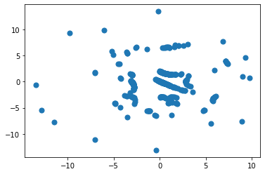

```
Data Armed
```

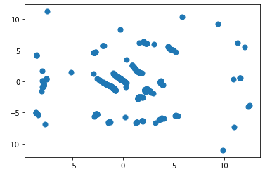

```
Data Race
```

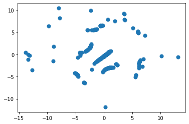

```python
print("Data")
scatter_nolabel(data,500)

print("Data Armed")
scatter_nolabel(data_armed,500)

print("Data Race")
scatter_nolabel(data_race,500)
```

#### DBScan

Estimate the Eps based on the distance from 4th nearest neighbor

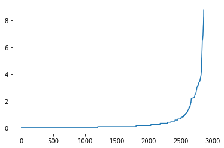

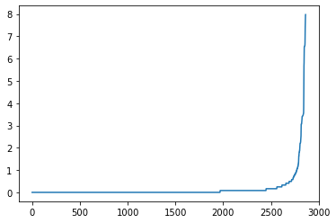

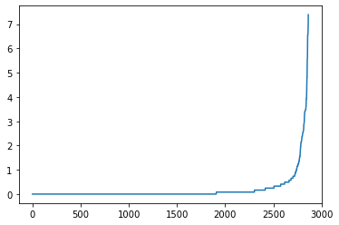

```python
for ca_data in ca_datasets:
    nn = NearestNeighbors(n_neighbors=4)
    nn.fit(ca_data)
    distances = nn.kneighbors()[0]
    fourth_distances = []

    for d in distances:
        fourth_distances.append(d[-1])
    fourth_distances.sort()

    plt.plot(fourth_distances)
    plt.show()
```

```
Data
Silhoutte score: 0.5153657644480877
```

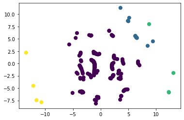

```
Data Armed
Silhoutte score: 0.5294341904869412
```

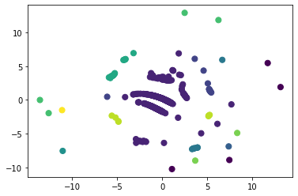

```
Data Race
Silhoutte score: 0.5790582757338637
```

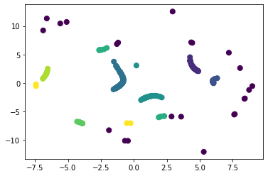

```python
dbscan = DBSCAN(min_samples=6, eps=7.5)
result = dbscan.fit_predict(data)
result = pd.Series(result)
silhoutteScore = silhouette_score(data, result)
print("Data")
print("Silhoutte score:", silhoutteScore)
scatter_label(data, result,500)

dbscan = DBSCAN(min_samples=6, eps=5)
result = dbscan.fit_predict(data_armed)
result = pd.Series(result)
silhoutteScore = silhouette_score(data_armed, result)
print("Data Armed")
print("Silhoutte score:", silhoutteScore)
scatter_label(data_armed, result,500)

dbscan = DBSCAN(min_samples=6, eps=1)
result = dbscan.fit_predict(data_race)
result = pd.Series(result)
silhoutteScore = silhouette_score(data_race, result)
print("Data Race")
print("Silhoutte score:", silhoutteScore)
scatter_label(data_race, result,500)
```

## Texas

Isolating data from Texas.

```python
tx_datasets = []
for i in range(len(datasets)):
    dataset = datasets[i]
    tx_data = dataset[dataset["State"] == "TX"].copy()
    tx_data = tx_data.drop("State", axis=1)
    tx_datasets.append(tx_data)

data, data_armed, data_race = tx_datasets
print("Data shape:", data.shape)
print("Data Armed shape:",data_armed.shape)
print("Data Race shape:",data_race.shape)
```

```
Data shape: (1152, 21)
Data Armed shape: (1152, 15)
Data Race shape: (1152, 17)
```

#### Feature Engineering

Feature reduction using PCA

```python
for i in range(len(tx_datasets)):
    tx_data = tx_datasets[i]
    scaler = StandardScaler()
    scaled_data = scaler.fit_transform(tx_data)
    pca = PCA(n_components=0.9995, svd_solver='full')
    pca_data = pca.fit_transform(scaled_data)

    tx_data = DataFrame(pca_data)
    tx_datasets[i] = tx_data

data, data_armed, data_race = tx_datasets
print("Data shape:", data.shape)
print("Data Armed shape:",data_armed.shape)
print("Data Race shape:",data_race.shape)
```

```
Data shape: (1152, 16)
Data Armed shape: (1152, 10)
Data Race shape: (1152, 12)
```

#### Raw data before cluster

```
Data
```

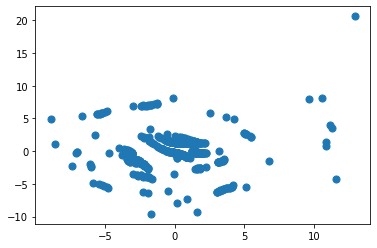

```
Data Armed
```

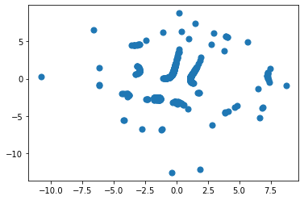

```
Data Race
```

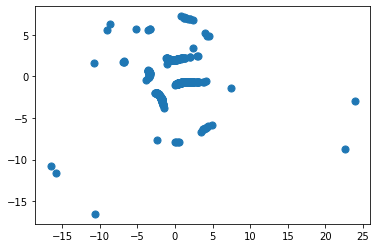

```python
print("Data")
scatter_nolabel(data,500)

print("Data Armed")
scatter_nolabel(data_armed,500)

print("Data Race")
scatter_nolabel(data_race,500)
```

#### DBScan

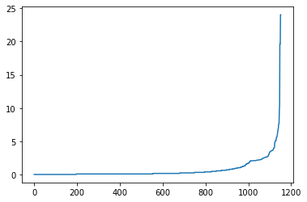

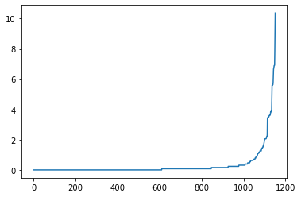

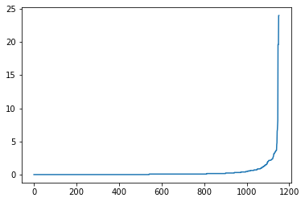

```python
for tx_data in tx_datasets:
    nn = NearestNeighbors(n_neighbors=4)
    nn.fit(tx_data)
    distances = nn.kneighbors()[0]
    fourth_distances = []

    for d in distances:
        fourth_distances.append(d[-1])
    fourth_distances.sort()

    plt.plot(fourth_distances)
    plt.show()
```

```
Data
Silhoutte Score: 0.6206837917009271
```

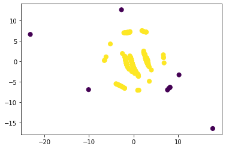

```
Data Armed
Silhoutte Score: 0.5674161125216362
```

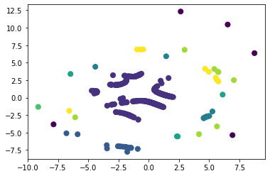

```
Data Race
Silhoutte Score: 0.4344737942306614
```

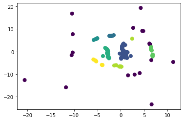

```python
dbscan = DBSCAN(min_samples=6, eps=7.5)
result = dbscan.fit_predict(data)
result = pd.Series(result)
silhoutteScore = silhouette_score(data, result)
print("Data")
print("Silhoutte Score:",silhoutteScore)
scatter_label(tx_data, result,500)

dbscan = DBSCAN(min_samples=6, eps=4)
result = dbscan.fit_predict(data_armed)
result = pd.Series(result)
silhoutteScore = silhouette_score(data_armed, result)
print("Data Armed")
print("Silhoutte Score:",silhoutteScore)
scatter_label(data_armed, result,500)

dbscan = DBSCAN(min_samples=6, eps=3)
result = dbscan.fit_predict(data_race)
result = pd.Series(result)
silhoutteScore = silhouette_score(data_race, result)
print("Data Race")
print("Silhoutte Score:",silhoutteScore)
scatter_label(data_race, result,500)
```